# 📈 Analyse de la saison 2022-2023 du Meetup Python de Grenoble

Cette **analyse** s'appuie sur les données du [Groupe d'utilisateurs Python - Grenoble](https://www.meetup.com/fr-FR/groupe-dutilisateurs-python-grenoble/) de la plateforme [Meetup](https://www.meetup.com/fr-FR/) pour les évènements de la **saison 2022-2023**. Une **analyse particulière** est faite pour analyser l'impact de l'**ancienneté dans le groupe Meetup** ainsi que le **genre** sur les inscriptions.

# ✅ Bilan des nouvelles inscriptions au groupe Meetup Python

## 🔢 Les principales métriques

Les métriques ont été calculées entre le **1er août 2022** et le **13 juillet 2023**.

### Nombre de **nouveaux inscrits** au groupe Meetup :

## **100 avec 21% 👩‍💻 et 79% 👨‍💻** (anciens inscrits 🎅 : 15% 👩‍💻 et 85% 👨‍💻)

### **Variation** du nombre d'inscrits au groupe Meetup depuis le 1er août 2022 :

## **+21 %** avec +30% 👩‍💻 et +19% 👨‍💻

### Nombre de **nouveaux inscrits** ayant participé **à au moins un** Meetup :

## **71 (15 👩‍💻 et 56 👨‍💻)**

## 📊 Les graphiques

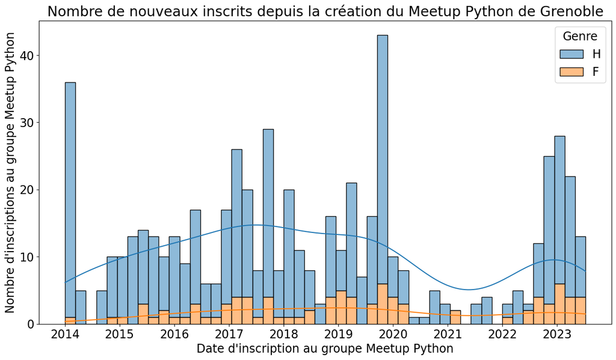

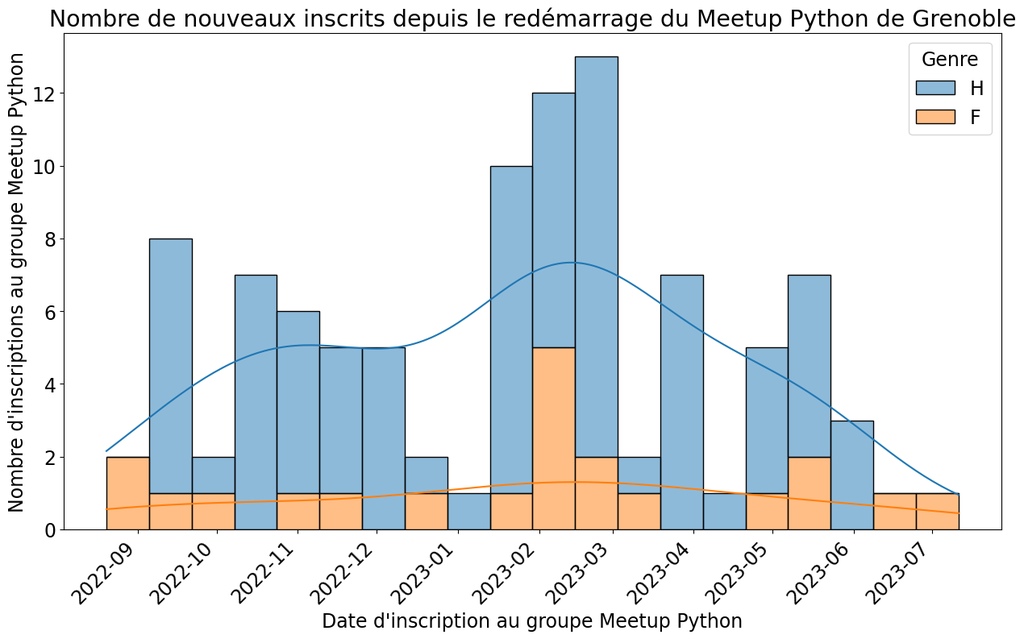

On observe un **maximum** de nouvelles inscriptions en **début d'année 2023** juste avant le Meetup [Python for Good](https://meetup-python-grenoble.github.io/events/2023-02-28/). On n'observe **pas de différence** de la répartition temporelle des nouvelles inscriptions **par genre**. L'impact des congés est notable en **fin d'année** et aux **vacances d'été**.

# ✅ Bilan des participations aux différents Meetups

## 🔢 Les principales métriques

## 🥇 Le Meetup de février 2023 [Python for Good](https://meetup-python-grenoble.github.io/events/2023-02-28/) a été le Meetup avec **le plus d'inscriptions** depuis la création du groupe en 2014 : 46 inscrits (et 9 désinscrits)

## **104 personnes (18% des personnes du groupe)** ont participé à au moins un Meetup : 71 nouveaux inscrits (68% | 21% 👩‍💻 et 79% 👨‍💻) et 33 anciens (32 % | 3% 👩‍💻 et 97% 👨‍💻)

## **229 inscriptions** aux différents Meetups de la saison 2022-2023

## 10 Meetups ont eu lieu sur la saison 2022-2023 (un par mois de septembre à juin) :

- **4 conférences/talks 🎤** : [Retour sur EuroPython 2022](https://meetup-python-grenoble.github.io/events/2022-09-29/) en septembre 2022, [À la quête de l'objet factice !](https://meetup-python-grenoble.github.io/events/2022-11-24/) en novembre 2022, [Créer des sites web Jupyter interactifs avec JupyterLite](https://meetup-python-grenoble.github.io/events/2023-03-28/) en mars 2023 et [Vous avez voté aux primaires des présidentielles ?](https://meetup-python-grenoble.github.io/events/2023-06-29/) en juin 2023.
- **2 quiz 🎲** : [Python Horror Show](https://meetup-python-grenoble.github.io/events/2022-10-25/) en octobre 2022 et [Retour ludique sur l’année pythonique 2022](https://meetup-python-grenoble.github.io/events/2023-01-26/) en janvier 2023.
- **2 ateliers/workshops 💻** : [Python for Good](https://meetup-python-grenoble.github.io/events/2023-02-28/) en février 2023 et [Exploration de données avec Datasette](https://meetup-python-grenoble.github.io/events/2023-05-25/) en mai 2023.
- **2 présentations courtes/lightning talks ⚡** : [Présentations Surprises !](https://meetup-python-grenoble.github.io/events/2022-12-15/) en décembre 2022 et [Lightning Talks](https://meetup-python-grenoble.github.io/events/2023-04-27/) en avril 2023.

## Moyennes et écart-types des participations aux Meetups :

- **4 conférences/talks 🎤** : 19 (écart-type : 4)
- **2 quiz 🎲** : 22 (écart-type : 0)
- **2 ateliers/workshops 💻** : 37 (écart-type : 9)
- **2 présentations courtes/lightning talks ⚡** : 18 (écart-type : 0)

## 📊 Les graphiques

Dans les données, les personnes inscrites au groupe Meetup **avant le 1er août 2022** sont considérés comme **"Ancien"**. Ceux qui se sont inscrits **après le 1er août 2022** sont considérés comme **"Nouveau"**.

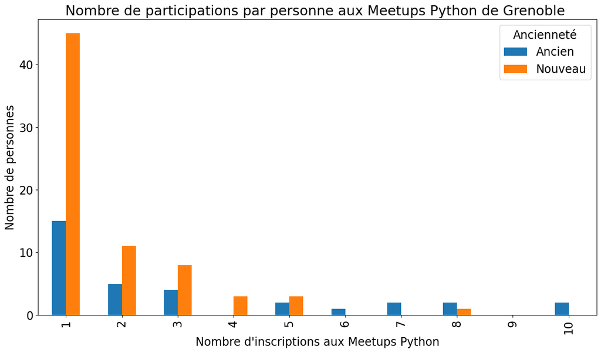

On observe une **surreprésentation des "anciens"** dans les personnes qui se sont inscrites à **plusieurs Meetups**. Néanmoins, cette analyse est **à relativiser** car les nouveaux inscrits au groupe se sont inscrits au cours de l'année.

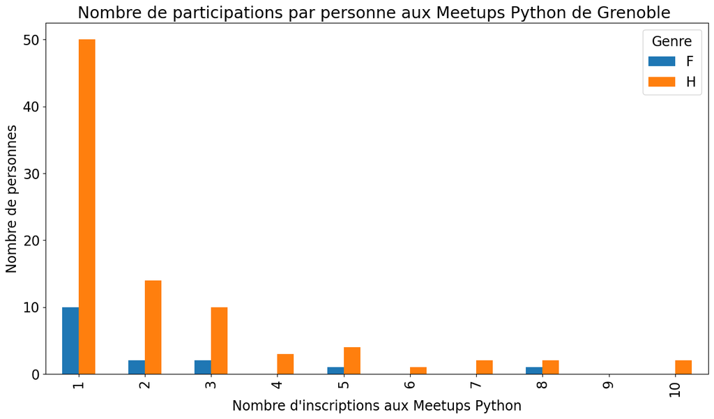

L'échantillon **statistique étant faible**, on ne peut pas tirer de conclusion sur la répartition par genre.

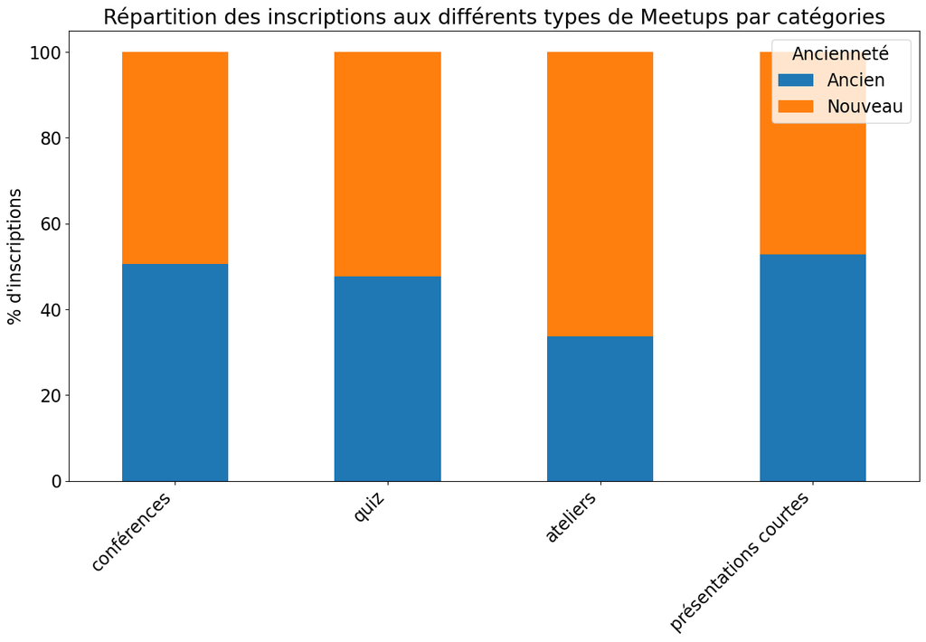

On observe que les **nouveaux inscrits** participent plus aux **ateliers** et dans une moindre mesure aux **quiz**.

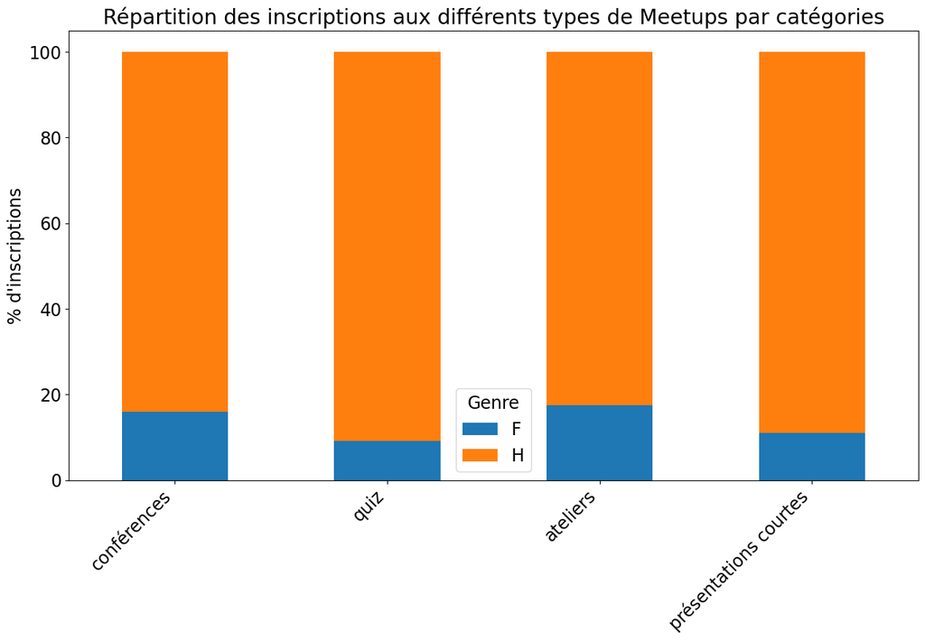

On observe que les **femmes** participent plus aux **ateliers** et aux **conférences**.